# Assignment 2

Problem Statement: During the COVID-19 pandemic, identifying whether individuals are wearing face masks has become a critical task. In this assignment, your objective is to develop a Convolutional Neural Network (CNN) model to classify face images as either "masked" or "unmasked."

Note: To simplify the task, the dataset provided primarily includes images with a single face and minimal background interference. However, in real-world scenarios, challenges such as multiple faces, varied backgrounds, and different types of masks (e.g., patterned masks, skin-tone masks) may arise.

Dataset Description: The dataset includes face images categorized into "masked" and "unmasked" folders. These images are further divided into training, validation, and testing sets, as shown below:

dataset/

- train_validate/
  - unmasked/ (840 images)
  - masked/ (840 images)
- test/
  - unmasked/ (160 images)
  - masked/ (160 images)

Download Link: Mask Detection Dataset

Tasks You may use Python libraries to solve the tasks outlined below:

Prepare the Dataset Load the dataset into appropriate data structures, ensuring images are resized to 64x64x3 to be fed as input to the CNN. [1 mark]

Build the CNN Model Using TensorFlow and Keras, create a CNN model with the following indicative architecture:

Convolution Layer → Activation Function (ReLU) → Pooling Layer (Convolution Layer → Activation Function) × 2 → Pooling Layer Fully Connected Layer → Activation Function Softmax Classifier Use a pool size of 2x2, filter size of 3x3, and any other standard parameters as needed. [2 marks]

Train the Model Train the model for 70 epochs (E=70). Log and plot the following metrics for each epoch:

Training Loss Training Accuracy Validation Loss Validation Accuracy Save these metrics and present them as a graph after training is complete. [4 marks]

Evaluate the Model Test the trained CNN on the testing dataset and print the classification metrics, including precision, recall, and F1-score. [2 marks]

Model Improvement Modify the default CNN model to improve its performance. For example, you may change hyperparameters, add layers, or use techniques like data augmentation. Compare the performance of the original ("default") and modified ("improved") models by plotting precision and recall side-by-side in a bar chart. [2 marks]

Visualize Predictions Display 5 sample images from the test set predicted as "masked" and 5 predicted as "unmasked." Include the predicted labels for each image. [1 mark]

## Task 1:- Prepare the Dataset

Load the dataset into appropriate data structures, ensuring images are resized to 64x64x3 to be fed as input to the CNN. [1 mark]

```python
# Importing required packages
import numpy as np
from sklearn.metrics import classification_report
from sklearn.metrics import classification_report
import tensorflow as tf
from tensorflow.keras.preprocessing.image import ImageDataGenerator
from tensorflow.keras import layers, models
import matplotlib.pyplot as plt
import os
```

```python
# Constants
BASE_DIR = os.getcwd()  # Get the current working directory
TRAIN_VAL_DIR = os.path.join(BASE_DIR, "train_validate-20250129T184506Z-001", "train_validate")
TEST_DIR = os.path.join(BASE_DIR, "test-20250129T184445Z-001", "test")

IMG_SIZE = (64, 64)
BATCH_SIZE = 32

def create_image_generator(rescale=1.0, validation_split=None, augment=False):
    """
    Create an ImageDataGenerator with optional data augmentation and validation split.
    """
    if augment:
        return ImageDataGenerator(
            rescale=rescale,
            validation_split=validation_split,
            rotation_range=20,
            width_shift_range=0.2,
            height_shift_range=0.2,
            horizontal_flip=True,
            zoom_range=0.2
        )
    return ImageDataGenerator(rescale=rescale, validation_split=validation_split)

def create_data_flow(directory, generator, target_size, batch_size, subset=None, shuffle=True):
    """
    Create a data flow object using a given ImageDataGenerator.
    """
    return generator.flow_from_directory(
        directory=directory,
        target_size=target_size,
        batch_size=batch_size,
        class_mode='categorical',
        subset=subset,
        shuffle=shuffle
    )

# Create data generators
train_val_generator = create_image_generator(rescale=1./255, validation_split=0.2, augment=True)
test_generator = create_image_generator(rescale=1./255)

# Prepare data flows
train_data = create_data_flow(TRAIN_VAL_DIR, train_val_generator, IMG_SIZE, BATCH_SIZE, subset="training")
val_data = create_data_flow(TRAIN_VAL_DIR, train_val_generator, IMG_SIZE, BATCH_SIZE, subset="validation")
test_data = create_data_flow(TEST_DIR, test_generator, IMG_SIZE, BATCH_SIZE, shuffle=False)

# Print class labels mapping
print("Class Labels Mapping:", train_data.class_indices)
```

```
Found 1343 images belonging to 2 classes.
Found 335 images belonging to 2 classes.
Found 320 images belonging to 2 classes.
Class Labels Mapping: {'masked': 0, 'unmasked': 1}
```

## Task 2:- Build the CNN Model

Using TensorFlow and Keras, create a CNN model with the following indicative architecture:

--> Convolution Layer → Activation Function (ReLU) → Pooling Layer

--> (Convolution Layer → Activation Function) × 2 → Pooling Layer

--> Fully Connected Layer → Activation Function

--> Softmax Classifier

Use a pool size of 2x2, filter size of 3x3, and any other standard parameters as needed. [2 marks]

```python
# Importing required packages
from tensorflow.keras.models import Sequential
from tensorflow.keras.layers import Conv2D, MaxPooling2D, Flatten, Dense, Dropout

def build_CNN_model():
    model = Sequential([
        Conv2D(32, (3, 3), activation='relu', input_shape=(64, 64, 3)),
        MaxPooling2D(pool_size=(2, 2)),

        Conv2D(64, (3, 3), activation='relu'),
        Conv2D(64, (3, 3), activation='relu'),
        MaxPooling2D(pool_size=(2, 2)),

        Flatten(),
        Dense(128, activation='relu'),
        Dropout(0.5),  # Regularization
        Dense(2, activation='softmax')  # Output layer
    ])

    model.compile(optimizer='adam',
                  loss='categorical_crossentropy',
                  metrics=['accuracy'])
    return model

# Build the model
CNN_model = build_CNN_model()
CNN_model.summary()
```

```
Model: "sequential_7"
```

```
┏━━━━━━━━━━━━━━━━━━━━━━━━━━━━━━━━━━━━━━┳━━━━━━━━━━━━━━━━━━━━━━━━━━━━━┳━━━━━━━━━━━━━━━━━┓
┃ Layer (type)                         ┃ Output Shape                ┃         Param # ┃
┡━━━━━━━━━━━━━━━━━━━━━━━━━━━━━━━━━━━━━━╇━━━━━━━━━━━━━━━━━━━━━━━━━━━━━╇━━━━━━━━━━━━━━━━━┩
│ conv2d_20 (Conv2D)                   │ (None, 62, 62, 32)          │             896 │
├──────────────────────────────────────┼─────────────────────────────┼─────────────────┤
│ max_pooling2d_16 (MaxPooling2D)      │ (None, 31, 31, 32)          │               0 │
├──────────────────────────────────────┼─────────────────────────────┼─────────────────┤
│ conv2d_21 (Conv2D)                   │ (None, 29, 29, 64)          │          18,496 │
├──────────────────────────────────────┼─────────────────────────────┼─────────────────┤
│ conv2d_22 (Conv2D)                   │ (None, 27, 27, 64)          │          36,928 │
├──────────────────────────────────────┼─────────────────────────────┼─────────────────┤
│ max_pooling2d_17 (MaxPooling2D)      │ (None, 13, 13, 64)          │               0 │
├──────────────────────────────────────┼─────────────────────────────┼─────────────────┤
│ flatten_7 (Flatten)                  │ (None, 10816)               │               0 │
├──────────────────────────────────────┼─────────────────────────────┼─────────────────┤
│ dense_14 (Dense)                     │ (None, 128)                 │       1,384,576 │
├──────────────────────────────────────┼─────────────────────────────┼─────────────────┤
│ dropout_6 (Dropout)                  │ (None, 128)                 │               0 │
├──────────────────────────────────────┼─────────────────────────────┼─────────────────┤
│ dense_15 (Dense)                     │ (None, 2)                   │             258 │
└──────────────────────────────────────┴─────────────────────────────┴─────────────────┘
```

```
 Total params: 1,441,154 (5.50 MB)
```

```
 Trainable params: 1,441,154 (5.50 MB)
```

```
 Non-trainable params: 0 (0.00 B)
```

## Task 3:- Train the Model

Train the model for 70 epochs (E=70). Log and plot the following metrics for each epoch:

--> Training Loss

--> Training Accuracy

--> Validation Loss

--> Validation Accuracy

Save these metrics and present them as a graph after training is complete. [4 marks]

```
42/42 ━━━━━━━━━━━━━━━━━━━━ 8s 149ms/step - accuracy: 0.6962 - loss: 0.6026 - val_accuracy: 0.9045 - val_loss: 0.2392
42/42 ━━━━━━━━━━━━━━━━━━━━ 6s 138ms/step - accuracy: 0.8796 - loss: 0.3170 - val_accuracy: 0.8985 - val_loss: 0.2754
42/42 ━━━━━━━━━━━━━━━━━━━━ 6s 133ms/step - accuracy: 0.8930 - loss: 0.2903 - val_accuracy: 0.8925 - val_loss: 0.2368
42/42 ━━━━━━━━━━━━━━━━━━━━ 6s 143ms/step - accuracy: 0.8919 - loss: 0.2366 - val_accuracy: 0.9284 - val_loss: 0.2021
42/42 ━━━━━━━━━━━━━━━━━━━━ 6s 143ms/step - accuracy: 0.9223 - loss: 0.2316 - val_accuracy: 0.9403 - val_loss: 0.1709
42/42 ━━━━━━━━━━━━━━━━━━━━ 6s 134ms/step - accuracy: 0.9169 - loss: 0.2419 - val_accuracy: 0.9373 - val_loss: 0.1715
42/42 ━━━━━━━━━━━━━━━━━━━━ 5s 127ms/step - accuracy: 0.9165 - loss: 0.2265 - val_accuracy: 0.8985 - val_loss: 0.2260
42/42 ━━━━━━━━━━━━━━━━━━━━ 6s 135ms/step - accuracy: 0.9107 - loss: 0.2517 - val_accuracy: 0.9642 - val_loss: 0.1479
42/42 ━━━━━━━━━━━━━━━━━━━━ 6s 144ms/step - accuracy: 0.9190 - loss: 0.2139 - val_accuracy: 0.9433 - val_loss: 0.1461
42/42 ━━━━━━━━━━━━━━━━━━━━ 6s 132ms/step - accuracy: 0.9413 - loss: 0.2021 - val_accuracy: 0.9582 - val_loss: 0.1342
42/42 ━━━━━━━━━━━━━━━━━━━━ 6s 136ms/step - accuracy: 0.9459 - loss: 0.1343 - val_accuracy: 0.9433 - val_loss: 0.1689
42/42 ━━━━━━━━━━━━━━━━━━━━ 6s 133ms/step - accuracy: 0.9250 - loss: 0.1880 - val_accuracy: 0.9403 - val_loss: 0.1847
42/42 ━━━━━━━━━━━━━━━━━━━━ 6s 134ms/step - accuracy: 0.9182 - loss: 0.2031 - val_accuracy: 0.9403 - val_loss: 0.1774
42/42 ━━━━━━━━━━━━━━━━━━━━ 6s 143ms/step - accuracy: 0.9505 - loss: 0.1365 - val_accuracy: 0.9403 - val_loss: 0.1543
42/42 ━━━━━━━━━━━━━━━━━━━━ 6s 139ms/step - accuracy: 0.9357 - loss: 0.1655 - val_accuracy: 0.9313 - val_loss: 0.1925
42/42 ━━━━━━━━━━━━━━━━━━━━ 6s 136ms/step - accuracy: 0.9394 - loss: 0.1743 - val_accuracy: 0.9403 - val_loss: 0.1748
42/42 ━━━━━━━━━━━━━━━━━━━━ 6s 133ms/step - accuracy: 0.9198 - loss: 0.2012 - val_accuracy: 0.9284 - val_loss: 0.1576
42/42 ━━━━━━━━━━━━━━━━━━━━ 6s 136ms/step - accuracy: 0.9348 - loss: 0.1760 - val_accuracy: 0.9552 - val_loss: 0.1604
42/42 ━━━━━━━━━━━━━━━━━━━━ 6s 144ms/step - accuracy: 0.9437 - loss: 0.1527 - val_accuracy: 0.9433 - val_loss: 0.1543
42/42 ━━━━━━━━━━━━━━━━━━━━ 6s 133ms/step - accuracy: 0.9298 - loss: 0.1877 - val_accuracy: 0.9493 - val_loss: 0.1614
42/42 ━━━━━━━━━━━━━━━━━━━━ 6s 142ms/step - accuracy: 0.9484 - loss: 0.1749 - val_accuracy: 0.9522 - val_loss: 0.1338
42/42 ━━━━━━━━━━━━━━━━━━━━ 6s 135ms/step - accuracy: 0.9332 - loss: 0.1602 - val_accuracy: 0.9403 - val_loss: 0.1529
42/42 ━━━━━━━━━━━━━━━━━━━━ 6s 142ms/step - accuracy: 0.9348 - loss: 0.1471 - val_accuracy: 0.9313 - val_loss: 0.1927
42/42 ━━━━━━━━━━━━━━━━━━━━ 6s 136ms/step - accuracy: 0.9420 - loss: 0.1471 - val_accuracy: 0.9313 - val_loss: 0.1852
42/42 ━━━━━━━━━━━━━━━━━━━━ 6s 140ms/step - accuracy: 0.9574 - loss: 0.1300 - val_accuracy: 0.9463 - val_loss: 0.1547
42/42 ━━━━━━━━━━━━━━━━━━━━ 6s 144ms/step - accuracy: 0.9494 - loss: 0.1442 - val_accuracy: 0.9433 - val_loss: 0.1600
42/42 ━━━━━━━━━━━━━━━━━━━━ 6s 145ms/step - accuracy: 0.9392 - loss: 0.1459 - val_accuracy: 0.9373 - val_loss: 0.1798
42/42 ━━━━━━━━━━━━━━━━━━━━ 6s 135ms/step - accuracy: 0.9474 - loss: 0.1461 - val_accuracy: 0.9373 - val_loss: 0.1728
42/42 ━━━━━━━━━━━━━━━━━━━━ 6s 147ms/step - accuracy: 0.9544 - loss: 0.1236 - val_accuracy: 0.9463 - val_loss: 0.1531
42/42 ━━━━━━━━━━━━━━━━━━━━ 6s 138ms/step - accuracy: 0.9509 - loss: 0.1434 - val_accuracy: 0.9463 - val_loss: 0.1507
42/42 ━━━━━━━━━━━━━━━━━━━━ 6s 142ms/step - accuracy: 0.9388 - loss: 0.1525 - val_accuracy: 0.9552 - val_loss: 0.1130
42/42 ━━━━━━━━━━━━━━━━━━━━ 6s 145ms/step - accuracy: 0.9682 - loss: 0.0909 - val_accuracy: 0.9463 - val_loss: 0.1665
42/42 ━━━━━━━━━━━━━━━━━━━━ 6s 137ms/step - accuracy: 0.9640 - loss: 0.1067 - val_accuracy: 0.9433 - val_loss: 0.1311
42/42 ━━━━━━━━━━━━━━━━━━━━ 6s 137ms/step - accuracy: 0.9483 - loss: 0.1524 - val_accuracy: 0.9403 - val_loss: 0.1913
42/42 ━━━━━━━━━━━━━━━━━━━━ 6s 141ms/step - accuracy: 0.9571 - loss: 0.1209 - val_accuracy: 0.9493 - val_loss: 0.1598
42/42 ━━━━━━━━━━━━━━━━━━━━ 6s 142ms/step - accuracy: 0.9582 - loss: 0.1308 - val_accuracy: 0.9463 - val_loss: 0.1869
42/42 ━━━━━━━━━━━━━━━━━━━━ 6s 132ms/step - accuracy: 0.9326 - loss: 0.1617 - val_accuracy: 0.9493 - val_loss: 0.1560
42/42 ━━━━━━━━━━━━━━━━━━━━ 6s 139ms/step - accuracy: 0.9576 - loss: 0.1283 - val_accuracy: 0.9433 - val_loss: 0.1771
42/42 ━━━━━━━━━━━━━━━━━━━━ 6s 134ms/step - accuracy: 0.9525 - loss: 0.1174 - val_accuracy: 0.9343 - val_loss: 0.2031
42/42 ━━━━━━━━━━━━━━━━━━━━ 6s 139ms/step - accuracy: 0.9481 - loss: 0.1521 - val_accuracy: 0.9582 - val_loss: 0.1308
```

[output cut: 15 more lines]

```
42/42 ━━━━━━━━━━━━━━━━━━━━ 6s 137ms/step - accuracy: 0.9625 - loss: 0.1077 - val_accuracy: 0.9582 - val_loss: 0.1673
42/42 ━━━━━━━━━━━━━━━━━━━━ 6s 136ms/step - accuracy: 0.9613 - loss: 0.1070 - val_accuracy: 0.9493 - val_loss: 0.1618
42/42 ━━━━━━━━━━━━━━━━━━━━ 6s 134ms/step - accuracy: 0.9567 - loss: 0.1240 - val_accuracy: 0.9373 - val_loss: 0.2073
42/42 ━━━━━━━━━━━━━━━━━━━━ 6s 139ms/step - accuracy: 0.9546 - loss: 0.1052 - val_accuracy: 0.9642 - val_loss: 0.1902
42/42 ━━━━━━━━━━━━━━━━━━━━ 6s 133ms/step - accuracy: 0.9761 - loss: 0.0633 - val_accuracy: 0.9493 - val_loss: 0.1613
42/42 ━━━━━━━━━━━━━━━━━━━━ 6s 135ms/step - accuracy: 0.9719 - loss: 0.0733 - val_accuracy: 0.9493 - val_loss: 0.2314
42/42 ━━━━━━━━━━━━━━━━━━━━ 6s 136ms/step - accuracy: 0.9692 - loss: 0.0701 - val_accuracy: 0.9403 - val_loss: 0.1588
42/42 ━━━━━━━━━━━━━━━━━━━━ 6s 141ms/step - accuracy: 0.9569 - loss: 0.1377 - val_accuracy: 0.9373 - val_loss: 0.2093
42/42 ━━━━━━━━━━━━━━━━━━━━ 6s 144ms/step - accuracy: 0.9411 - loss: 0.1784 - val_accuracy: 0.9493 - val_loss: 0.1721
42/42 ━━━━━━━━━━━━━━━━━━━━ 6s 142ms/step - accuracy: 0.9644 - loss: 0.1041 - val_accuracy: 0.9373 - val_loss: 0.2453
42/42 ━━━━━━━━━━━━━━━━━━━━ 6s 134ms/step - accuracy: 0.9692 - loss: 0.0976 - val_accuracy: 0.9403 - val_loss: 0.2306
42/42 ━━━━━━━━━━━━━━━━━━━━ 6s 140ms/step - accuracy: 0.9652 - loss: 0.1054 - val_accuracy: 0.9493 - val_loss: 0.1612
42/42 ━━━━━━━━━━━━━━━━━━━━ 6s 140ms/step - accuracy: 0.9686 - loss: 0.0901 - val_accuracy: 0.9701 - val_loss: 0.1681
42/42 ━━━━━━━━━━━━━━━━━━━━ 6s 138ms/step - accuracy: 0.9636 - loss: 0.1015 - val_accuracy: 0.9493 - val_loss: 0.1700
42/42 ━━━━━━━━━━━━━━━━━━━━ 6s 146ms/step - accuracy: 0.9567 - loss: 0.1143 - val_accuracy: 0.9433 - val_loss: 0.1871
```

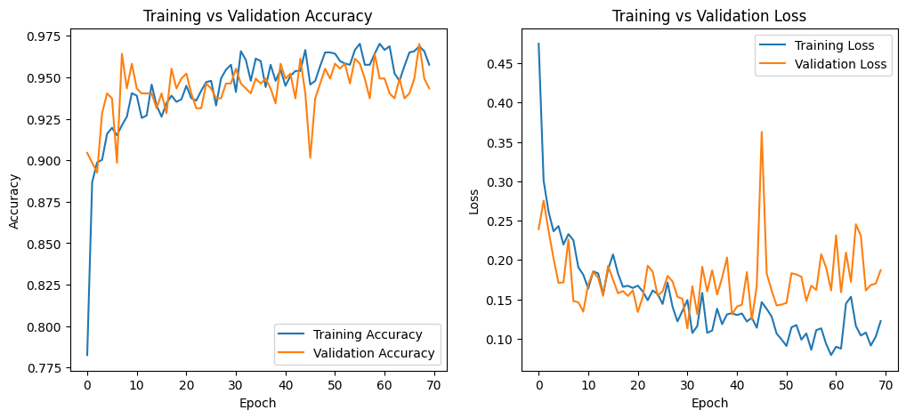

```python
# Train the model (use the 'model' variable from earlier)
history = CNN_model.fit(train_data, epochs=70,
                    validation_data=val_data)

# Plot training history
plt.figure(figsize=(12, 5))

# Plot accuracy
plt.subplot(1, 2, 1)
plt.plot(history.history['accuracy'], label='Training Accuracy')
plt.plot(history.history['val_accuracy'], label='Validation Accuracy')
plt.xlabel('Epoch')
plt.ylabel('Accuracy')
plt.legend()
plt.title('Training vs Validation Accuracy')

# Plot loss
plt.subplot(1, 2, 2)
plt.plot(history.history['loss'], label='Training Loss')
plt.plot(history.history['val_loss'], label='Validation Loss')
plt.xlabel('Epoch')
plt.ylabel('Loss')
plt.legend()
plt.title('Training vs Validation Loss')

# Show the plots
plt.show()
```

## Task 4:- Evaluate the Model

Test the trained CNN on the testing dataset and print the classification metrics, including precision, recall, and F1-score. [2 marks]

```python
from sklearn.metrics import classification_report

# Assuming 'test_data' contains the test images and 'test_labels' contains the corresponding labels
# You might need to adjust the data according to your actual variable names.

# Step 1: Make predictions on the test set
test_predictions = CNN_model.predict(test_data)

# Step 2: Convert predicted probabilities to class labels (0 or 1 for binary classification)
predicted_classes = test_predictions.argmax(axis=1)  # For binary or multi-class classification

# Step 3: Get the true class labels
true_classes = test_data.classes # Assuming test_labels are one-hot encoded, if not, just use test_labels directly.

# Step 4: Generate classification report
report = classification_report(true_classes, predicted_classes, target_names=['masked', 'unmasked'])

# Print the classification metrics
print("Classification Report:\n",report)
```

```
10/10 ━━━━━━━━━━━━━━━━━━━━ 1s 106ms/step
Classification Report:
               precision    recall  f1-score   support

      masked       0.86      0.91      0.89       160
    unmasked       0.91      0.86      0.88       160

    accuracy                           0.88       320
   macro avg       0.89      0.88      0.88       320
weighted avg       0.89      0.88      0.88       320
```

## Task 5:-Model Improvement

Modify the default CNN model to improve its performance. For example, you may change hyperparameters, add layers, or use techniques like data augmentation. Compare the performance of the original ("default") and modified ("improved") models by plotting precision and recall side-by-side in a bar chart. [2 marks]

### To improve the performance of a Convolutional Neural Network (CNN), we can apply several techniques like adjusting hyperparameters, adding layers, or using data augmentation. Here's how you can approach this task step by step:

#### Step 1. Default CNN Model

The default CNN model can be a simple architecture. For example, consider the following basic CNN structure:

```python
# Importing required packages
from tensorflow.keras.models import Sequential
from tensorflow.keras.layers import Conv2D, MaxPooling2D, Flatten, Dense, Dropout

def build_CNN_model():
    model = Sequential([
        Conv2D(32, (3, 3), activation='relu', input_shape=(64, 64, 3)),
        MaxPooling2D(pool_size=(2, 2)),

        Conv2D(64, (3, 3), activation='relu'),
        Conv2D(64, (3, 3), activation='relu'),
        MaxPooling2D(pool_size=(2, 2)),

        Flatten(),
        Dense(128, activation='relu'),
        Dropout(0.5),  # Regularization
        Dense(2, activation='softmax')  # Output layer
    ])

    model.compile(optimizer='adam',
                  loss='categorical_crossentropy',
                  metrics=['accuracy'])
    return model

# Build the model
CNN_model = build_CNN_model()
```

#### Step 2. Improved CNN Model

For improving performance, we can:

--> Use Batch Normalization to stabilize and speed up training.

```python
from tensorflow.keras.layers import BatchNormalization

def build_improved_model():
    model = Sequential([
        Conv2D(32, (3, 3), activation='relu', input_shape=(64, 64, 3)),
        BatchNormalization(),
        MaxPooling2D(pool_size=(2, 2)),

        Conv2D(64, (3, 3), activation='relu'),
        BatchNormalization(),
        Conv2D(64, (3, 3), activation='relu'),
        BatchNormalization(),
        MaxPooling2D(pool_size=(2, 2)),

        Flatten(),
        Dense(256, activation='relu'),
        Dropout(0.5),
        Dense(2, activation='softmax')
    ])

    model.compile(optimizer='adam',
                  loss='categorical_crossentropy',
                  metrics=['accuracy'])
    return model

# Train improved model
improved_model = build_improved_model()
history_improved = improved_model.fit(train_data, epochs=70, validation_data=val_data)
```

```
42/42 ━━━━━━━━━━━━━━━━━━━━ 15s 258ms/step - accuracy: 0.7930 - loss: 1.6362 - val_accuracy: 0.6776 - val_loss: 1.8728
42/42 ━━━━━━━━━━━━━━━━━━━━ 7s 176ms/step - accuracy: 0.9086 - loss: 0.7176 - val_accuracy: 0.5015 - val_loss: 6.6504
42/42 ━━━━━━━━━━━━━━━━━━━━ 7s 167ms/step - accuracy: 0.8996 - loss: 0.5179 - val_accuracy: 0.5701 - val_loss: 2.2219
42/42 ━━━━━━━━━━━━━━━━━━━━ 7s 172ms/step - accuracy: 0.9085 - loss: 0.3700 - val_accuracy: 0.6269 - val_loss: 2.4328
42/42 ━━━━━━━━━━━━━━━━━━━━ 7s 173ms/step - accuracy: 0.9007 - loss: 0.3946 - val_accuracy: 0.5045 - val_loss: 7.0093
42/42 ━━━━━━━━━━━━━━━━━━━━ 7s 170ms/step - accuracy: 0.9159 - loss: 0.3087 - val_accuracy: 0.5015 - val_loss: 15.2860
42/42 ━━━━━━━━━━━━━━━━━━━━ 7s 171ms/step - accuracy: 0.9256 - loss: 0.2439 - val_accuracy: 0.5463 - val_loss: 6.8610
42/42 ━━━━━━━━━━━━━━━━━━━━ 7s 176ms/step - accuracy: 0.9133 - loss: 0.2523 - val_accuracy: 0.5254 - val_loss: 8.8404
42/42 ━━━━━━━━━━━━━━━━━━━━ 7s 174ms/step - accuracy: 0.9367 - loss: 0.1766 - val_accuracy: 0.5940 - val_loss: 7.7771
42/42 ━━━━━━━━━━━━━━━━━━━━ 7s 172ms/step - accuracy: 0.9206 - loss: 0.2363 - val_accuracy: 0.6239 - val_loss: 1.5684
42/42 ━━━━━━━━━━━━━━━━━━━━ 7s 163ms/step - accuracy: 0.9467 - loss: 0.1739 - val_accuracy: 0.8299 - val_loss: 0.5902
42/42 ━━━━━━━━━━━━━━━━━━━━ 7s 173ms/step - accuracy: 0.9433 - loss: 0.1962 - val_accuracy: 0.9164 - val_loss: 0.3768
42/42 ━━━━━━━━━━━━━━━━━━━━ 7s 169ms/step - accuracy: 0.9303 - loss: 0.2088 - val_accuracy: 0.8925 - val_loss: 0.3445
42/42 ━━━━━━━━━━━━━━━━━━━━ 7s 173ms/step - accuracy: 0.9482 - loss: 0.1535 - val_accuracy: 0.7642 - val_loss: 1.4761
42/42 ━━━━━━━━━━━━━━━━━━━━ 7s 165ms/step - accuracy: 0.9445 - loss: 0.1736 - val_accuracy: 0.9373 - val_loss: 0.3660
42/42 ━━━━━━━━━━━━━━━━━━━━ 7s 171ms/step - accuracy: 0.9476 - loss: 0.1496 - val_accuracy: 0.9493 - val_loss: 0.2196
42/42 ━━━━━━━━━━━━━━━━━━━━ 7s 175ms/step - accuracy: 0.9430 - loss: 0.1660 - val_accuracy: 0.9164 - val_loss: 0.3798
42/42 ━━━━━━━━━━━━━━━━━━━━ 7s 170ms/step - accuracy: 0.9600 - loss: 0.1346 - val_accuracy: 0.9015 - val_loss: 0.5008
42/42 ━━━━━━━━━━━━━━━━━━━━ 7s 170ms/step - accuracy: 0.9578 - loss: 0.1346 - val_accuracy: 0.9254 - val_loss: 0.2506
42/42 ━━━━━━━━━━━━━━━━━━━━ 7s 172ms/step - accuracy: 0.9592 - loss: 0.1218 - val_accuracy: 0.9104 - val_loss: 0.2145
42/42 ━━━━━━━━━━━━━━━━━━━━ 7s 173ms/step - accuracy: 0.9479 - loss: 0.1448 - val_accuracy: 0.5672 - val_loss: 3.2680
42/42 ━━━━━━━━━━━━━━━━━━━━ 7s 169ms/step - accuracy: 0.9539 - loss: 0.1652 - val_accuracy: 0.9552 - val_loss: 0.1435
42/42 ━━━━━━━━━━━━━━━━━━━━ 7s 176ms/step - accuracy: 0.9352 - loss: 0.1777 - val_accuracy: 0.9463 - val_loss: 0.1673
42/42 ━━━━━━━━━━━━━━━━━━━━ 7s 176ms/step - accuracy: 0.9619 - loss: 0.0918 - val_accuracy: 0.9194 - val_loss: 0.2380
42/42 ━━━━━━━━━━━━━━━━━━━━ 7s 173ms/step - accuracy: 0.9583 - loss: 0.1212 - val_accuracy: 0.9463 - val_loss: 0.1499
42/42 ━━━━━━━━━━━━━━━━━━━━ 7s 175ms/step - accuracy: 0.9569 - loss: 0.1259 - val_accuracy: 0.9672 - val_loss: 0.1339
42/42 ━━━━━━━━━━━━━━━━━━━━ 7s 172ms/step - accuracy: 0.9642 - loss: 0.0945 - val_accuracy: 0.4985 - val_loss: 4.9681
42/42 ━━━━━━━━━━━━━━━━━━━━ 7s 168ms/step - accuracy: 0.9588 - loss: 0.0988 - val_accuracy: 0.8507 - val_loss: 0.3312
42/42 ━━━━━━━━━━━━━━━━━━━━ 7s 173ms/step - accuracy: 0.9448 - loss: 0.1496 - val_accuracy: 0.8896 - val_loss: 0.2950
42/42 ━━━━━━━━━━━━━━━━━━━━ 7s 167ms/step - accuracy: 0.9623 - loss: 0.1155 - val_accuracy: 0.9433 - val_loss: 0.1239
42/42 ━━━━━━━━━━━━━━━━━━━━ 7s 174ms/step - accuracy: 0.9629 - loss: 0.1346 - val_accuracy: 0.9642 - val_loss: 0.1406
42/42 ━━━━━━━━━━━━━━━━━━━━ 7s 171ms/step - accuracy: 0.9640 - loss: 0.1092 - val_accuracy: 0.5463 - val_loss: 5.8765
42/42 ━━━━━━━━━━━━━━━━━━━━ 7s 169ms/step - accuracy: 0.9593 - loss: 0.1337 - val_accuracy: 0.9104 - val_loss: 0.2290
42/42 ━━━━━━━━━━━━━━━━━━━━ 7s 174ms/step - accuracy: 0.9625 - loss: 0.1301 - val_accuracy: 0.5224 - val_loss: 2.1568
42/42 ━━━━━━━━━━━━━━━━━━━━ 8s 178ms/step - accuracy: 0.9594 - loss: 0.1160 - val_accuracy: 0.9194 - val_loss: 0.2835
42/42 ━━━━━━━━━━━━━━━━━━━━ 7s 171ms/step - accuracy: 0.9641 - loss: 0.1145 - val_accuracy: 0.6776 - val_loss: 0.6513
42/42 ━━━━━━━━━━━━━━━━━━━━ 7s 176ms/step - accuracy: 0.9503 - loss: 0.1275 - val_accuracy: 0.9433 - val_loss: 0.1990
42/42 ━━━━━━━━━━━━━━━━━━━━ 7s 171ms/step - accuracy: 0.9589 - loss: 0.1461 - val_accuracy: 0.9284 - val_loss: 0.2097
42/42 ━━━━━━━━━━━━━━━━━━━━ 7s 168ms/step - accuracy: 0.9731 - loss: 0.0965 - val_accuracy: 0.9582 - val_loss: 0.2367
42/42 ━━━━━━━━━━━━━━━━━━━━ 7s 166ms/step - accuracy: 0.9686 - loss: 0.1027 - val_accuracy: 0.8836 - val_loss: 0.4355
```

[output cut: 15 more lines]

```
42/42 ━━━━━━━━━━━━━━━━━━━━ 7s 167ms/step - accuracy: 0.9718 - loss: 0.0714 - val_accuracy: 0.9164 - val_loss: 0.2141
42/42 ━━━━━━━━━━━━━━━━━━━━ 7s 164ms/step - accuracy: 0.9603 - loss: 0.1139 - val_accuracy: 0.9672 - val_loss: 0.1608
42/42 ━━━━━━━━━━━━━━━━━━━━ 7s 171ms/step - accuracy: 0.9743 - loss: 0.0849 - val_accuracy: 0.9552 - val_loss: 0.1103
42/42 ━━━━━━━━━━━━━━━━━━━━ 7s 174ms/step - accuracy: 0.9739 - loss: 0.0802 - val_accuracy: 0.9642 - val_loss: 0.1212
42/42 ━━━━━━━━━━━━━━━━━━━━ 7s 171ms/step - accuracy: 0.9760 - loss: 0.0657 - val_accuracy: 0.9701 - val_loss: 0.1149
42/42 ━━━━━━━━━━━━━━━━━━━━ 7s 170ms/step - accuracy: 0.9747 - loss: 0.0718 - val_accuracy: 0.9463 - val_loss: 0.2777
42/42 ━━━━━━━━━━━━━━━━━━━━ 7s 174ms/step - accuracy: 0.9718 - loss: 0.1442 - val_accuracy: 0.6746 - val_loss: 1.7598
42/42 ━━━━━━━━━━━━━━━━━━━━ 7s 176ms/step - accuracy: 0.9663 - loss: 0.1186 - val_accuracy: 0.9403 - val_loss: 0.3955
42/42 ━━━━━━━━━━━━━━━━━━━━ 7s 171ms/step - accuracy: 0.9600 - loss: 0.1251 - val_accuracy: 0.6299 - val_loss: 9.6778
42/42 ━━━━━━━━━━━━━━━━━━━━ 7s 166ms/step - accuracy: 0.9528 - loss: 0.2260 - val_accuracy: 0.4955 - val_loss: 7.1845
42/42 ━━━━━━━━━━━━━━━━━━━━ 7s 166ms/step - accuracy: 0.9715 - loss: 0.0835 - val_accuracy: 0.5433 - val_loss: 2.8430
42/42 ━━━━━━━━━━━━━━━━━━━━ 7s 172ms/step - accuracy: 0.9710 - loss: 0.1102 - val_accuracy: 0.7612 - val_loss: 0.7189
42/42 ━━━━━━━━━━━━━━━━━━━━ 7s 168ms/step - accuracy: 0.9692 - loss: 0.1120 - val_accuracy: 0.9075 - val_loss: 0.3456
42/42 ━━━━━━━━━━━━━━━━━━━━ 8s 184ms/step - accuracy: 0.9739 - loss: 0.0779 - val_accuracy: 0.8985 - val_loss: 0.4546
42/42 ━━━━━━━━━━━━━━━━━━━━ 7s 178ms/step - accuracy: 0.9727 - loss: 0.1020 - val_accuracy: 0.9642 - val_loss: 0.1205
```

#### Step 3:- Model Comparison (Precision and Recall)

```
10/10 ━━━━━━━━━━━━━━━━━━━━ 1s 51ms/step
10/10 ━━━━━━━━━━━━━━━━━━━━ 1s 65ms/step
```

[figure not shown]

[figure not shown]

```python
from sklearn.metrics import classification_report
import matplotlib.pyplot as plt

# Step 1: Predict using the default model
test_predictions_default = default_model.predict(test_data)
predicted_classes_default = test_predictions_default.argmax(axis=1)

# Step 2: Predict using the improved model
test_predictions_improved = improved_model.predict(test_data)
predicted_classes_improved = test_predictions_improved.argmax(axis=1)

# Step 3: Get the true class labels
true_classes = test_data.classes

# Step 4: Get the classification reports for both models
report_default = classification_report(true_classes, predicted_classes_default, output_dict=True)
report_improved = classification_report(true_classes, predicted_classes_improved, output_dict=True)

# Extract precision and recall for the default model
precision_default = [
    report_default[str(i)]['precision'] for i in range(len(train_data.class_indices))
]
recall_default = [
    report_default[str(i)]['recall'] for i in range(len(train_data.class_indices))
]

# Extract precision and recall for the improved model
precision_improved = [
    report_improved[str(i)]['precision'] for i in range(len(train_data.class_indices))
]
recall_improved = [
    report_improved[str(i)]['recall'] for i in range(len(train_data.class_indices))
]

# Step 6: Plot the comparison
# Class names for labels
class_names = list(train_data.class_indices.keys())

# Set up the bar width and positions
x = np.arange(len(class_names))  # [0, 1] for two classes
width = 0.25  # Bar width

plt.figure(figsize=(10, 6))

# Plot Precision
plt.bar(x - width / 2, precision_default, width, label='Default Model')
plt.bar(x + width / 2, precision_improved, width, label='Improved Model')

plt.xlabel('Class')
plt.ylabel('Precision')
plt.title('Precision Comparison')
plt.xticks(x, class_names)  # Use class names as labels
plt.legend()

plt.show()

# Plot Recall
plt.figure(figsize=(10, 8))

plt.bar(x - width / 2, recall_default, width, label='Default Model')
plt.bar(x + width / 2, recall_improved, width, label='Improved Model')

plt.xlabel('Class')
plt.ylabel('Recall')
plt.title('Recall Comparison')
plt.xticks(x, class_names)  # Use class names as labels
plt.legend()

plt.show()
```

## Task 6:- Visualize Predictions

Display 5 sample images from the test set predicted as "masked" and 5 predicted as "unmasked." Include the predicted labels for each image. [1 mark]

```
10/10 ━━━━━━━━━━━━━━━━━━━━ 1s 57ms/step
```

[figure not shown]

```python
# Importing required package
import random

# Predict labels for the test dataset
y_pred_probs = improved_model.predict(test_data)
y_pred_classes = np.argmax(y_pred_probs, axis=1)  # Convert probabilities to class labels

# True labels
y_true_classes = test_data.classes
class_labels = {0: "Masked", 1: "Unmasked"}

# Get indices of masked and unmasked predictions
masked_indices = np.where(y_pred_classes == 0)[0]  # Indices where the model predicted "Masked"
unmasked_indices = np.where(y_pred_classes == 1)[0]  # Indices where the model predicted "Unmasked"

# Randomly select 5 masked and 5 unmasked samples
masked_samples = random.sample(list(masked_indices), 5)
unmasked_samples = random.sample(list(unmasked_indices), 5)

# Combine selected indices
selected_indices = masked_samples + unmasked_samples

# Plot the selected images with their predicted labels
plt.figure(figsize=(12, 6))

for i, idx in enumerate(selected_indices):
    img_path = test_data.filepaths[idx]  # Get image path
    img = plt.imread(img_path)  # Read image

    # Get the predicted label
    predicted_label = class_labels[y_pred_classes[idx]]

    # Plot image
    plt.subplot(2, 5, i + 1)
    plt.imshow(img)
    plt.title(f"Pred: {predicted_label}")
    plt.axis("off")

plt.tight_layout()
plt.show()
```